# README

[figure not shown]

## Campo Pixel

*Uma biblioteca R inteligente que transforma pixels em insights na agricultura.*

O pacote **CampoPixel** tem como objetivo **mapear a saúde das plantas** e o **percentual de solo exposto** a partir de **imagens RGB** capturadas por celulares, drones e satélites.  
Ele oferece um fluxo simples: **carregar → processar → visualizar/quantificar**, com foco em reprodutibilidade e desempenho.

## Captura de imagens em campo

Para obter bons resultados, priorize **imagens bem iluminadas, nítidas e sem sombras** sobre a área de interesse.

**Roteiro prático (clique para expandir)**

- Câmera reta ao solo (perpendicular), sem inclinação.
- Evitar ângulos >10° que causem distorções.
- Preferir luz difusa (céu nublado ou com nuvens finas).
- Evitar sol direto ao meio-dia e sombras sobre a área.
- Centralizar a cultura/solo, ocupar >80% do quadro.
- Não incluir pessoas, máquinas ou objetos no fundo.
- Resolução mínima: 180 PPI; formatos: .jpg, .png, .tif.
- Padronizar altura (ex.: 1,5 m solo; 0,5 m folhas).
- Capturar ≥3 imagens por ponto/talhão.
- Evitar vento forte ou solo encharcado/reflexivo.
- Nomear arquivos: `data_local_talhao_cultura_rep.jpg`.
- Organizar por pastas diárias de captura.

## Exemplo visual de captura

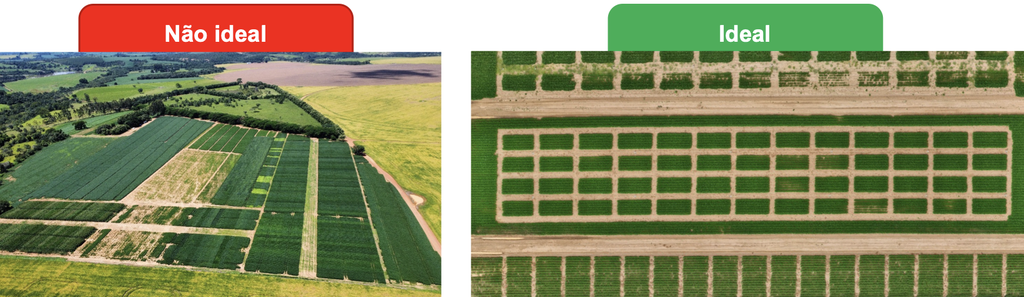

## Exemplos de aplicação

A seguir, exemplos que ilustram a diferença entre a imagem original e o resultado após processamento pelo **CampoPixel**.

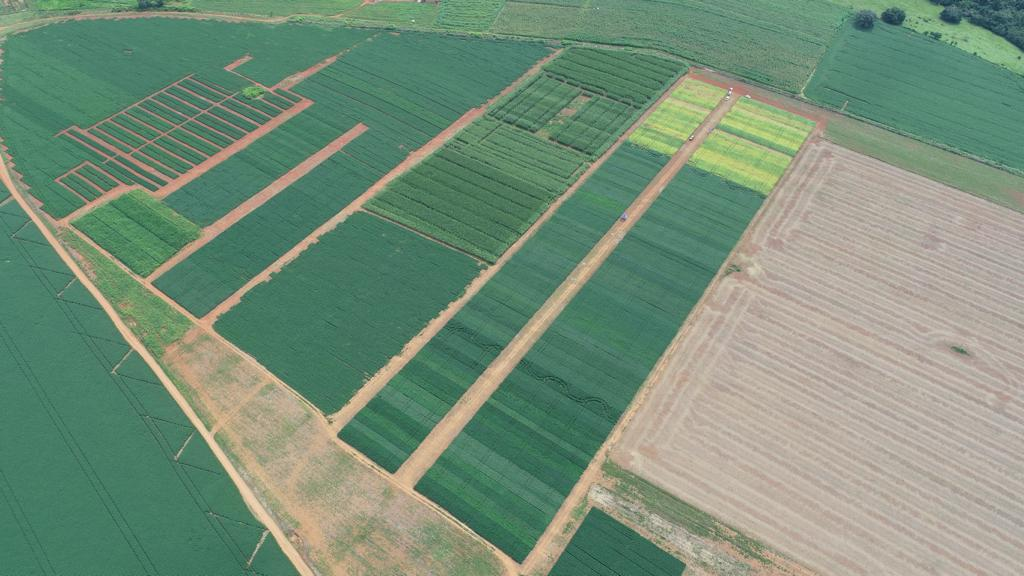

*Imagem original (RGB capturada por drone)*

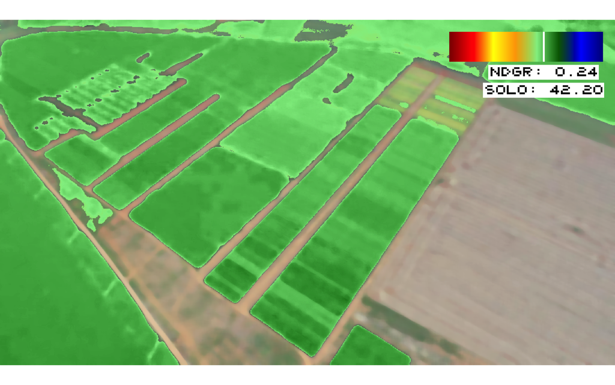

*Imagem processada (saída gerada pelo pacote)*

Essas figuras demonstram como o pacote transforma uma imagem RGB convencional em uma representação segmentada, evidenciando áreas de solo exposto, cobertura vegetal e variações de sanidade foliar.

### 1. **NDGR – Normalized Difference Green-Red Index**

O **NDGR** (*Normalized Difference Green-Red Index*) é um índice espectral que mede a diferença relativa entre os canais **verde (G)** e **vermelho (R)** da imagem.  
Sua fórmula é:

$$NDGR = \frac{G - R}{G + R}$$

- **G**: intensidade da banda verde.
- **R**: intensidade da banda vermelha.

Esse índice destaca áreas com maior presença de verde em relação ao vermelho, permitindo identificar vegetação ativa quando não há disponibilidade de bandas no infravermelho (como NDVI).  
É uma métrica útil em análises de imagens RGB capturadas por drones, câmeras ou satélites de baixa resolução.

Esta é a escala de cores utilizada para o **NDGR**.

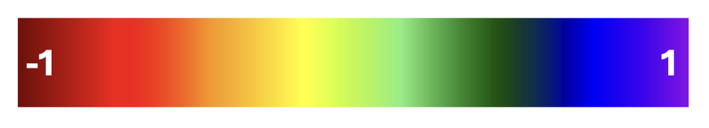

O índice varia de **-1 a 1**: quanto menor o valor, menor a reflectância associada à vegetação, indicando áreas de solo exposto ou baixa cobertura vegetal.

### 2. **Solo – Percentual de Solo Exposto**

O indicador **Solo** representa o **percentual de solo exposto** na imagem.

- Se a saída indicar **60% de solo exposto**, significa que os outros **40% correspondem à vegetação** (ou outros elementos não classificados como solo).
- O cálculo é realizado por meio de **segmentação da imagem RGB**, em que os pixels são classificados em duas grandes categorias: **solo** e **vegetação**.
- Após a segmentação, é feita a razão entre o número de pixels classificados como solo e o total da imagem, resultando em um valor percentual.

Esse indicador é fundamental para estudos de **cobertura vegetal, erosão e práticas de manejo agrícola**, pois fornece uma visão quantitativa do quanto da superfície está descoberta.

### 3. **Resumo Técnico: `process_img()`**

| Parâmetro / Saída | Significado | Método / Descrição |
| --- | --- | --- |
| `true_color` | Imagem original | RGB sem redimensionamento, rotação ou filtros |
| `NDGR` | Índice verde–vermelho normalizado | $(G - R) / (G + R)$ com bandas RGB |
| `im_binary` | Segmentação binária | Máscara onde pixels com vegetação são 1, solo é `NA` |
| `solo_exp` | Percentual de solo exposto | Proporção de pixels com valor `NA` em `im_binary` |
| `rgb_map` | Mapa colorido do NDGR | Gradiente de cor aplicado aos valores de NDGR segmentados |
| `NDGR_medio` | Valor médio do NDGR | Média dos valores válidos de NDGR após segmentação |
| `Imagem_final` | Imagem sobreposta com gradiente NDGR | Combinação da imagem original com o mapa NDGR colorido |

### 4. **Resumo Técnico: `crop_im()`**

| Parâmetro / Saída | Significado | Método / Descrição |
| --- | --- | --- |
| `x` | Imagem de entrada | Pode ser um objeto `Image` ou caminho para arquivo |
| `n_points` | Número de vértices | Define interativamente o polígono de recorte (mínimo de 3 pontos) |
| `display.it` | Exibir resultado ao final | Valor lógico (`TRUE` ou `FALSE`) |
| **Retorno** | Imagem RGB recortada | Recorte da menor caixa delimitadora que contém o polígono desenhado |

### 5. **Resumo Técnico: `resize_im()`**

| Parâmetro / Saída | Significado | Método / Descrição |
| --- | --- | --- |
| `x` | Imagem de entrada | Pode ser um objeto `Image` ou caminho para arquivo |
| `percentual` | Percentual de escala | Valor numérico entre 1 e 100; define a nova proporção da imagem |
| **Retorno** | Imagem RGB redimensionada | Imagem reduzida proporcionalmente com base no percentual informado |

## Configurações do `CampoPixel`

```r
if (!require(devtools)) install.packages("devtools")
devtools::install_github("wilhanvalasco/CampoPixel")
library(CampoPixel)
```

### Funções

```r
process_img()

Processa uma imagem RGB, calcula índices (ex.: NDGR) e estima métricas como **percentual de solo exposto**, além de gerar artefatos visuais úteis (mapas e sobreposições).
```

```r
crop_im()

Recorta uma região de interesse para análises locais ou para padronizar áreas entre múltiplas imagens.
```

```r
resize_im()

Reduz a imagem original para uma porcentagem da dimensão, mantendo a proporção entre largura e altura.
```

### Exemplos

```r
library(CampoPixel)

# Caminho para a sua imagem:
img_path <- "/caminho/para/sua/imagem.jpg"

# Processamento principal
res <- process_img(file_path = img_path, max_pixels = 5e6, angulo = 0)

# Ajuda e exemplos:
help(process_img)
help(crop_im)
```

## Desenvolvedores

Wilhan Valasco

Eng. Agrônomo · Me. Prot. Plantas · MBA Gestão · Esp. Data Science · Doutorando Biotecnologia/Biodversidade (IF Goiano).

✉️ wilhanvalasco@hotmail.com

Walter Baida

Eng. Agrônomo · Me. Prot. Plantas · Esp. Bioinsumos · Doutorando Estatística/Biometria (UFV).

✉️ walterbgc@gmail.com